# Practical machine learning: Project

V. Kirilenko

Saturday, May 23, 2015

## Summary

The purpose of this study was to predict the class of the power lift execution, other words to predict “how well” an activity was performed by the participants. Class A corresponds to the specified execution of the exercise, while the other 4 classes correspond to common mistakes. Dataset and information can be download from here: [Human Activity Recognition](http://groupware.les.inf.puc-rio.br/har). According to the results of machine learning and analysis of the constructed models was achieved overall accuracy of prediction in 98,3% (1 error from 60 predictions).

### *Data Processing*

First, we need a data for work.

```r
url1 = "http://d396qusza40orc.cloudfront.net/predmachlearn/pml-training.csv"
url2 = "http://d396qusza40orc.cloudfront.net/predmachlearn/pml-testing.csv"
temp = tempfile()
download.file(url1, temp)
train_tmp = read.csv(temp,na.strings=c("NA",""), header=TRUE, stringsAsFactors = FALSE)
download.file(url2, temp)
test_tmp = read.csv(temp, na.strings=c("NA",""), header=TRUE, stringsAsFactors = FALSE)
unlink(temp)
```

In our dataset we have a lot of column with NA values or with time values. All of them useless for our study.  
So we must remove them from training and testing datasets.

```r
set.seed(3422)
test = test_tmp[,unlist(lapply(1:ncol(test_tmp),function(x) (sum(is.na(test_tmp[,x]))/nrow(test_tmp))<0.9))]
train = train_tmp[,unlist(lapply(1:ncol(train_tmp),function(x) (sum(is.na(train_tmp[,x]))/nrow(train_tmp))<0.9))]
train$classe <- as.factor(train$classe)
train[,6]=NULL; train[,5]=NULL; train[,4]=NULL; train[,3]=NULL; train[,1]=NULL
trcv = trainControl(method="cv", number=10)
test[,6]=NULL; test[,5]=NULL; test[,4]=NULL; test[,3]=NULL; test[,1]=NULL
parts = createDataPartition(y=train$classe, p=.70, list=F)
worktrain = train[parts,]
valid = train[-parts,]
```

### *Model training*

After cleaning data we can build our model.  
We can choose 3 models for independent control of the results.

**First:** *Regularized Discriminant Analysis*.  
This is more robust and simple version of linear discriminant analysis and it is most effective in case of model with many predictors(as in our case).  
This model is made with 10 k-fold cross-validation.

**Second:** *Stochastic Gradient Boosting*.  
GBM method will build binary trees, i.e., partition the data into two samples at each split node. Its strong side is balance between approximation accuracy and execution speed. In our study it was the fastest model (approx. ~20 min.). This model is made with 10 k-fold cross-validation.

**Third:** *Random Forest*.  
This model is one of the most popular machine learning methods thanks to their good accuracy, robustness and ease of use. Random forest model is very effective in work with variables with non-obvious relationships, but it can be biased towards variables with many categories.  
This model is made without cross-validation, because **random** in the name of the method points to a random sample of predictors to build the tree.  
Therefore, cross-validation does not make any sense. Also this is needed to compare results of the models with cross-validation and without it.  
This model was built with out-of-bag control. The out-of-bag error is internal error estimate of a random forest as it is being constructed.

```r
train_rda_cv = train(classe ~ ., method="rda", trControl = trcv, tuneLength = 4, data=train)
train_gbm_cv = train(classe ~ ., method="gbm", trControl = trcv, distribution="multinomial", data=train)
train_rf_oob_w = train(classe ~., data=worktrain, trControl = trrf, method = "rf")
rda_test = predict(train_rda_cv, newdata = test)
gbm_test = predict(train_gbm_cv, newdata = test)
rf_test = predict(train_rf_oob_w, newdata = test)
```

### *Evaluation of the results*

Now we can check accuracy and errors of our models, also we can evaluate importance of the predictors.

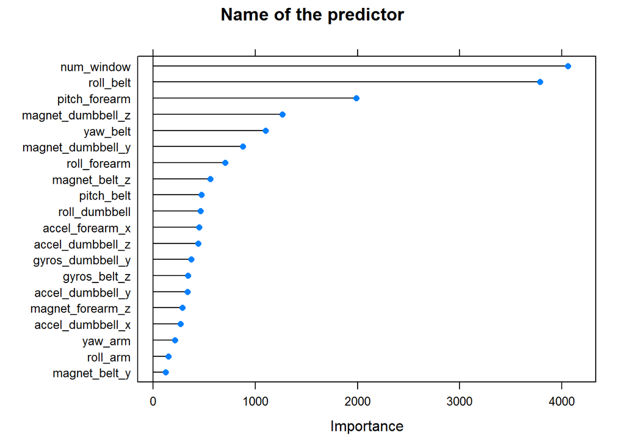

```r
variance = varImp(train_gbm_cv, scale = FALSE)
plot(variance, top = 20, main = "Name of the predictor")
```

```r
train_rf_oob_w$finalModel
```

```
##
## Call:
##  randomForest(x = x, y = y, mtry = param$mtry)
##                Type of random forest: classification
##                      Number of trees: 500
## No. of variables tried at each split: 30
##
##         OOB estimate of  error rate: 0.23%
## Confusion matrix:
##      A    B    C    D    E class.error
## A 3906    0    0    0    0 0.000000000
## B    3 2652    3    0    0 0.002257336
## C    0    7 2389    0    0 0.002921536
## D    0    0    9 2242    1 0.004440497
## E    0    1    0    7 2517 0.003168317
```

```r
resamps = resamples(list(GBM = train_gbm_cv, RDA = train_rda_cv))
summary(resamps)
```

```
##
## Call:
## summary.resamples(object = resamps)
##
## Models: GBM, RDA
## Number of resamples: 10
##
## Accuracy
##       Min. 1st Qu. Median   Mean 3rd Qu.   Max. NA's
## GBM 0.9857  0.9873 0.9878 0.9888  0.9906 0.9934    0
## RDA 0.9089  0.9125 0.9151 0.9146  0.9163 0.9200    0
##
## Kappa
##       Min. 1st Qu. Median   Mean 3rd Qu.   Max. NA's
## GBM 0.9819  0.9839 0.9845 0.9858  0.9881 0.9916    0
## RDA 0.8849  0.8894 0.8928 0.8921  0.8942 0.8988    0
```

```r
difValues = diff(resamps)
summary(difValues)
```

```
##
## Call:
## summary.diff.resamples(object = difValues)
##
## p-value adjustment: bonferroni
## Upper diagonal: estimates of the difference
## Lower diagonal: p-value for H0: difference = 0
##
## Accuracy
##     GBM       RDA
## GBM           0.0742
## RDA 5.141e-13
##
## Kappa
##     GBM       RDA
## GBM           0.09376
## RDA 5.123e-13
```

```r
pred = predict(train_rf_oob_w, valid)
confusionMatrix(pred,valid$classe)
```

```
## Confusion Matrix and Statistics
##
##           Reference
## Prediction    A    B    C    D    E
##          A 1672    4    0    0    0
##          B    1 1133    1    0    0
##          C    0    1 1025    1    0
##          D    0    1    0  963    1
##          E    1    0    0    0 1081
##
## Overall Statistics
##
##                Accuracy : 0.9981
##                  95% CI : (0.9967, 0.9991)
##     No Information Rate : 0.2845
##     P-Value [Acc > NIR] : < 2.2e-16
##
##                   Kappa : 0.9976
##  Mcnemar's Test P-Value : NA
##
## Statistics by Class:
##
##                      Class: A Class: B Class: C Class: D Class: E
## Sensitivity            0.9988   0.9947   0.9990   0.9990   0.9991
## Specificity            0.9991   0.9996   0.9996   0.9996   0.9998
## Pos Pred Value         0.9976   0.9982   0.9981   0.9979   0.9991
## Neg Pred Value         0.9995   0.9987   0.9998   0.9998   0.9998
## Prevalence             0.2845   0.1935   0.1743   0.1638   0.1839
## Detection Rate         0.2841   0.1925   0.1742   0.1636   0.1837
## Detection Prevalence   0.2848   0.1929   0.1745   0.1640   0.1839
## Balanced Accuracy      0.9989   0.9972   0.9993   0.9993   0.9994
```

**Information:x86_64-w64-mingw32, x86_64, mingw32, x86_64, mingw32, , 3, 1.3, 2015, 03, 09, 67962, R, R version 3.1.3 (2015-03-09), Smooth Sidewalk**  
**Last edition: 12:39:54 24/05/2015**